# SAR and Soil Moisture

Jonathan Bahlmann

### Packages and wd

```r
setwd("/home/petra/Praktikum")
library(stars)
```

```r
library(dplyr)
library(rgdal)
library(gdalUtils)
library(raster)
library(lubridate)
library(sp)
library(ggplot2)
library(zoo)
```

### Clipping of Intensity bands and precipitation dataset

is done with `gdal_translate -projwin 715088 5864849 773006 5840651 -projwin_srs "EPSG:25832" "D:/COPY/BEWAMO/intensity_2018_vh.tif" "D:/soil_moist/VH_clip.tif"` The window is (X,Y) UL 715088 5864849 LR 773006 5840651. It was done to shrink the amount of data that has to be loaded into memory (in case we need to load whole datasets).

### loading data

`read_stars` is used. option `proxy = TRUE` keeps the data from being read into memory. However proxy and non-proxy (‘pure’ stars) objects can’t be combined with `c()` operator. So either precipitation dataset is only combined later in dataframes or intensity bands must be read into memory. We keep the big rasters as proxies as long as possible and load them later, when we also subset into the polygon of interest.

#### tif datasets

```r
int_VV <- read_stars("VV_clip.tif", proxy=TRUE)
int_VH <- read_stars("VH_clip.tif", proxy=TRUE)
rain <- read_stars("rain_clip.tif")
```

#### shape

transform into crs of intensity dataset.

```r
shape <- read_sf("antragsfl_16_17_18.shp")
shape <- st_transform(shape, crs=st_crs(int_VV))
```

## aggregate rain data

Rain data is summarized over 3 days. Of these 3 day-sums, every 4th sum is selected to match sentinel 1 acquisition dates. 9 days between sums are not included in dataset.

```r
# sequence of all days in 2018
all_days <- seq(as.Date("2018-01-01"), as.Date("2018-12-31"), by="days")
# assign to rain stars
rain <- st_set_dimensions(rain, 3, values = all_days, names = "time")
# summarize every three days
rain <- aggregate(rain, by="3 days", sum)
# sequence of every fourth sum, so that sums then correspond to intensity dates
i <- as.vector(seq(from = 1, length.out = 31, by = 4))
# select from rain dataset. 3-day-sums from days before a S 1 acquisition.
rain <- rain[,i,,]
```

### warp rain dataset to exact geometry of intensity dataset

This is done with the aggregated data to lower workload.

```r
rain <- st_warp(rain, int_VV)
```

### dimensions and names

Dimensions cannot be assigned to proxy. We only assign to rain here.

```r
# these are the sentinel 1 acqusition dates
dates <- c(ymd("2018-01-03"), ymd("2018-01-15"), ymd("2018-01-27"), ymd("2018-02-08"), ymd("2018-02-20"), ymd("2018-03-04"), ymd("2018-03-16"), ymd("2018-03-28"), ymd("2018-04-09"), ymd("2018-04-21"), ymd("2018-05-03"), ymd("2018-05-15"), ymd("2018-05-27"), ymd("2018-06-08"), ymd("2018-06-20"), ymd("2018-07-02"), ymd("2018-07-14"), ymd("2018-07-26"), ymd("2018-08-07"), ymd("2018-08-19"), ymd("2018-08-31"), ymd("2018-09-12"), ymd("2018-09-24"), ymd("2018-10-06"), ymd("2018-10-18"), ymd("2018-10-30"), ymd("2018-11-11"), ymd("2018-11-23"), ymd("2018-12-05"), ymd("2018-12-17"), ymd("2018-12-29"))
# assign to rain ds
rain <- st_set_dimensions(rain, 3, values = dates, names = "time")
```

Assign attribute names:

```r
names(int_VV) <- "VV"
names(int_VH) <- "VH"
names(rain) <- "prec"
```

### Bind

#### proxy -> memory

Select polygon to scale down dataset and load into memory with `st_as_stars`. Because rain is not a proxy and we can’t combine it with proxy objects.

```r
# select polygon nr 123, the approximately largest area in sponsorship
# it seems important to do this seperately for the both int bands
int_vv <- st_as_stars(int_VV[shape[123,]])
int_vh <- st_as_stars(int_VH[shape[123,]])
# set dimensions to match rain dimensions
int_vv <- st_set_dimensions(int_vv, 3, values = dates, names = "time")
int_vh <- st_set_dimensions(int_vh, 3, values = dates, names = "time")
# class is now
class(int_vv)
```

```
## [1] "stars"
```

#### combine

Then combine all three. Give `along = "bands"` so that all attributes are treated as bands.

```r
# c()
comb <- c(int_vv, int_vh, rain[shape[123,]], along="bands")
# comb is now
comb
```

```
## stars object with 4 dimensions and 1 attribute
## attribute(s):
##       VV
##  Min.   :-24.88
##  1st Qu.:-18.49
##  Median :-14.74
##  Mean   :-10.45
##  3rd Qu.:  0.00
##  Max.   : 19.40
##  NA's   :133176
## dimension(s):
##       from   to     offset   delta                refsys point values x/y
## x     4744 4792     715082      10 ETRS89 / UTM zone 32N FALSE   NULL [x]
## y      857  921    5864854     -10 ETRS89 / UTM zone 32N FALSE   NULL [y]
## time     1   31 2018-01-03 12 days                  Date    NA   NULL
## bands    1    3         NA      NA                    NA    NA   NULL
```

### Change bands back to attributes

```r
comb_split <- split(comb, "bands")
# Gotta assign new names now, in order we combined them.
names(comb_split) <- c("VV", "VH", "prec")
comb_split
```

```
## stars object with 3 dimensions and 3 attributes
## attribute(s):
##       VV               VH              prec
##  Min.   :-20.23   Min.   :-24.88   Min.   : 0.00
##  1st Qu.:-15.91   1st Qu.:-20.73   1st Qu.: 0.00
##  Median :-14.74   Median :-19.67   Median : 0.30
##  Mean   :-14.62   Mean   :-19.58   Mean   : 2.85
##  3rd Qu.:-13.27   3rd Qu.:-18.44   3rd Qu.: 4.20
##  Max.   : -8.68   Max.   :-14.55   Max.   :19.40
##  NA's   :44392    NA's   :44392    NA's   :44392
## dimension(s):
##      from   to     offset   delta                refsys point values x/y
## x    4744 4792     715082      10 ETRS89 / UTM zone 32N FALSE   NULL [x]
## y     857  921    5864854     -10 ETRS89 / UTM zone 32N FALSE   NULL [y]
## time    1   31 2018-01-03 12 days                  Date    NA   NULL
```

### Aggregate spatially

We want a time series of the reflectance and precipitation for the whole polygon (whole dataset). Using `st_apply` to aggregate.

```r
comb_aggr <- st_apply(comb_split, "time", mean, na.rm = TRUE)
# and write as.data.frame for structure
dff <- as.data.frame(comb_aggr)
```

### plot

Keep in mind that precipitation data is a 3-day sum with 9-day breaks, ignoring all other precipitation in that period.

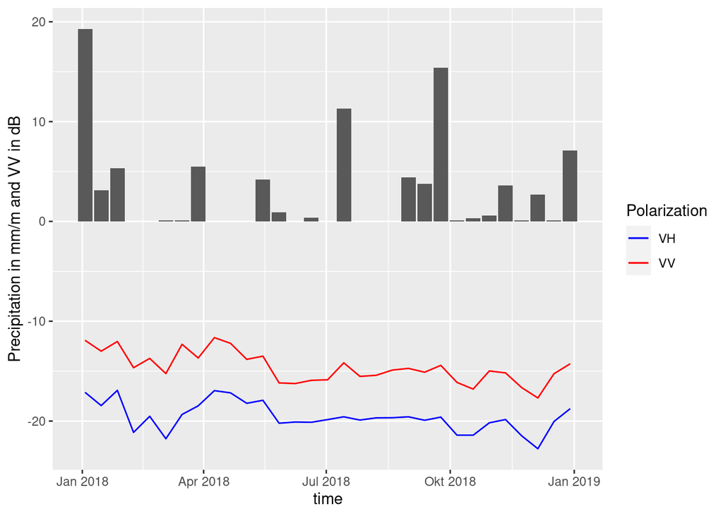

```r
ggplot(dff, aes(x=time)) +
  geom_line(aes(y = VV, color="VV")) +
  geom_line(aes(y = VH, color="VH")) +
  geom_bar(aes(y = prec), stat='identity') +
  ylab("Precipitation in mm/m and VV in dB") +
  scale_color_manual(name="Polarization", values=c(VV="red", VH="blue"))
```

## Alternative: aggregate rain every X days

When we handle intensity and rain data independent of each other, we can accumulate rain at independent dates. rain dates then don’t need to exactly match intensity data. Also: The above method only worked because S 1 data starts on 03/01 in the first place.

```r
# load
rainx <- read_stars("rain_clip.tif")
# set dims (all days)
rainx <- st_set_dimensions(rainx, 3, values = all_days, names = "time")
```

Now aggregate by X days. In this case: 6

```r
# aggregate
rainx <- aggregate(rainx, by="6 days", sum)
# warp again
rainx <- st_warp(rainx, int_VV)
# select shape
rainx <- rainx[shape[123,]]
```

When looking at the rainx dates (typing `rainx` and looking at offset; or `plot(rainx)`) we notice that the 6 day sums are dated on the first day of their sum. That is inconvenient for plotting them against intensity. We therefore date them onto the last day of their sum.

Also `st_apply` and `as.data.frame`.

```r
# set actual dates
calc.days <- seq(as.Date("2018-01-06"), as.Date("2018-12-31"), by="6 days")
rainx <- st_set_dimensions(rainx[,,,1:60], 3, values = calc.days, names = "time")
# resolve, same as above
rain.a <- st_apply(rainx, "time", mean, na.rm = TRUE)
rain.df <- as.data.frame(rain.a)
```

### Merge with intensity data to data frame

The main difference is that this time, we merge rain and int only at the dataframe level, not into a single stars object.

```r
# merge the above rain df and the intensity part of dff
# we need all x and y to keep all dates, not just the overlapping ones
ms <- merge(rain.df, dff[,1:3], all.x=TRUE, all.y=TRUE)
# change 'mean' to 'prec'
names(ms) <- c("time", "prec", "VV", "VH")
```

Since we now have a bunch of NAs we should do something with them.

```r
# ms stays our not approximated df
ms.app <- ms
# na.approx
ms.app$prec <- na.approx(as.vector(ms$prec), na.rm="FALSE")
ms.app$VV <- na.approx(as.vector(ms$VV), na.rm="FALSE")
ms.app$VH <- na.approx(as.vector(ms$VH), na.rm="FALSE")
# values that couldn't be approximated are set as 0
ms.app[is.na(ms.app)] <- 0
#
# ms.app[1,3] <- -11.9
```

## Results

let’s see. This shows us a 6 day precipitation sum with no breaks. So 6 days sum every 6 days. Keep in mind that precipitation fell over all the preceding 6 days.

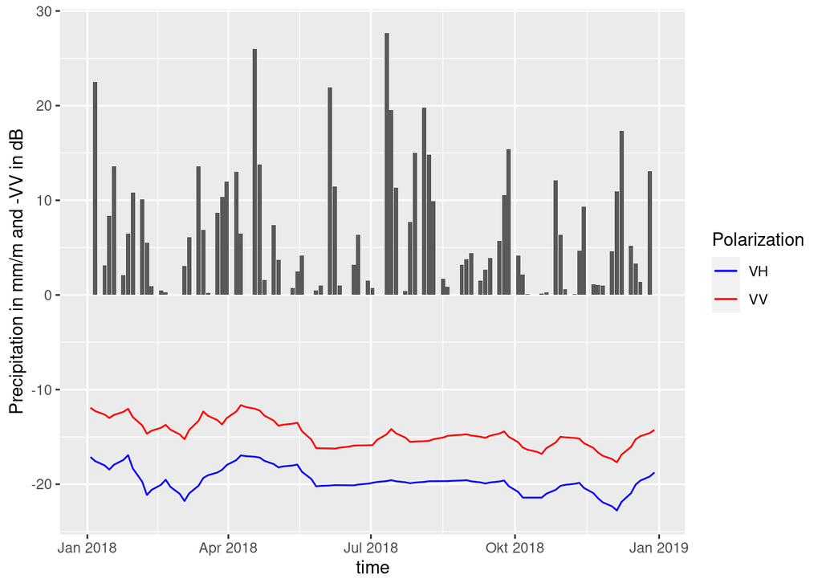

```r
ggplot(ms.app, aes(x=time)) +
  geom_bar(aes(y = prec), stat='identity') +
  geom_line(aes(y = VV, color = "VV")) +
  geom_line(aes(y = VH, color = "VH")) +
  ylab("Precipitation in mm/m and -VV in dB") +
  scale_color_manual(name="Polarization", values=c(VV="red", VH="blue"))
```

And for comparison, the 3-day sum + 9-day break with no approximation in intensity dataset:

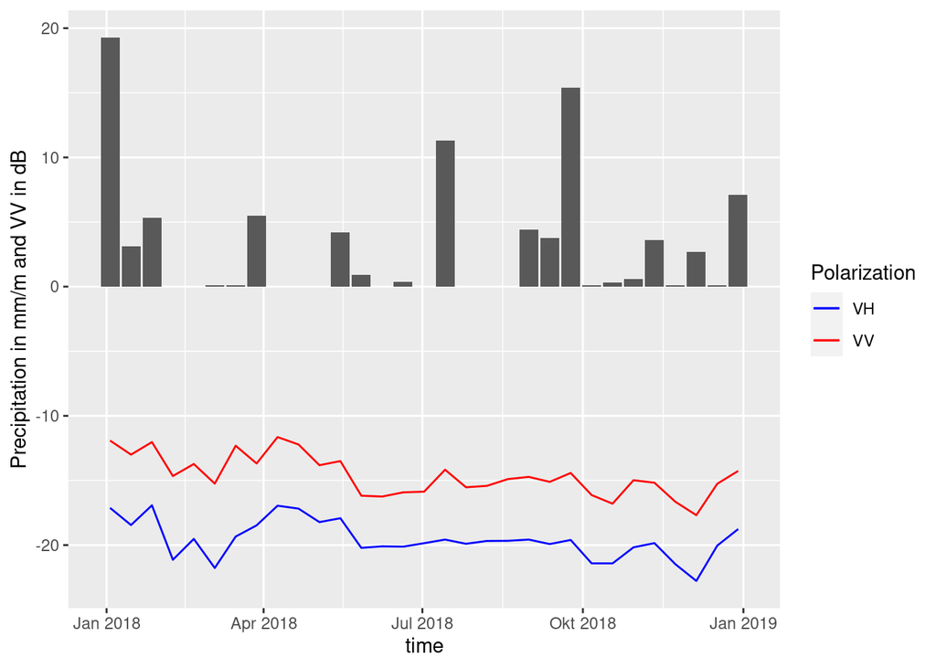

## Try a difference VV - VH

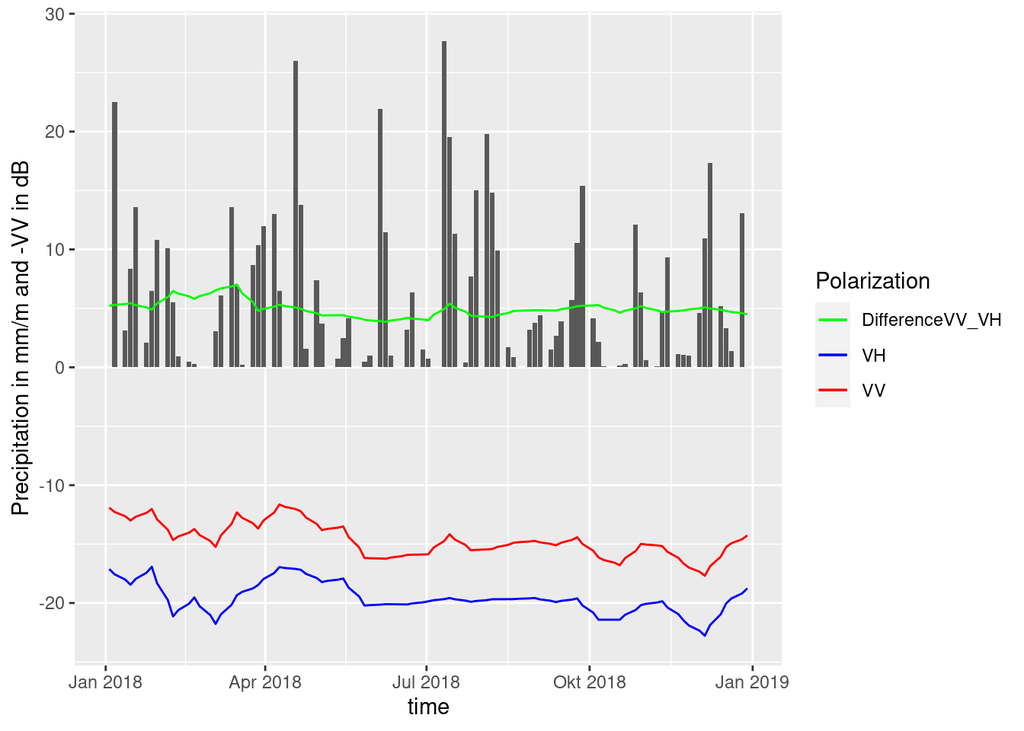

```r
# should be easy in df
ms.app$diff <- ms.app$VV - ms.app$VH
ms.app$diff.swap <- ms.app$VH - ms.app$VV
ggplot(ms.app, aes(x=time)) +
  geom_bar(aes(y = prec), stat='identity') +
  geom_line(aes(y = VV, color = "VV")) +
  geom_line(aes(y = VH, color = "VH")) +
  geom_line(aes(y = diff, color = "DifferenceVV_VH")) +
# geom_line(aes(y = diff.swap, color = "DifferenceVH_VV")) +
  ylab("Precipitation in mm/m and -VV in dB") +
  scale_color_manual(name="Polarization", values=c(VV="red", VH="blue", DifferenceVV_VH="green"
# ,DifferenceVH_VV="lightgreen"
  ))
```

Try this in stars object.

```r
# assign difference to new attribute
comb_split$VVminusVH <- comb_split["VV",,,] - comb_split["VH"]
# collapse time dimension / build mean over time
comb_spat <- st_apply(comb_split, c("x", "y"), mean, na.rm=TRUE)
```

Try this as RGB

```r
ras <- as(comb_spat, "Raster") # surpress warnings
```

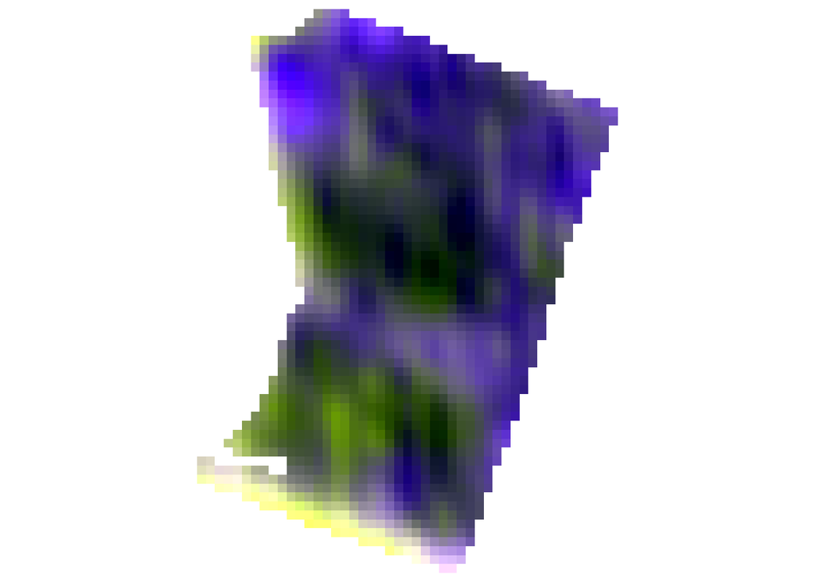

```r
plotRGB(ras, r=1, g=2, b=4, stretch="lin") # VV, VH, Diff
```